# Diamonds Project

Cameron Collett

February 16, 2018

## Background

Diamonds are valuable gems that are often used when proposing marriage. Student’s at BYU - Idaho are at a time in their lives when they are considering proposal with a ring. Many have very fixed budgets. We have been provided with a data set that contains tens of thousands of different diamonds and variables of the diamonds like cut, color, carat, dimensions and costs. Because these students are proposing to the love of their lives, they want the best cut and best colors available so we will only use “D” colored diamonds and “Ideal” cut diamonds. We will base our regression after this subsetted data. Carat is the variable in question. We want a regression of Price and Carat for these particular diamonds.

```r
diamonds1 <- diamonds %>%
  filter(cut == "Ideal" & color == "D")
```

## Our X variable: PRICE

From the plot below, we can see that the price is skewed to one side for diamonds with ideal cuts and color “D”. The bulk of our prices lie below $5000. Because most students wouldn’t be able to afford a diamond over $5000, we will only look for ideal cut diamonds under the price of $5000.

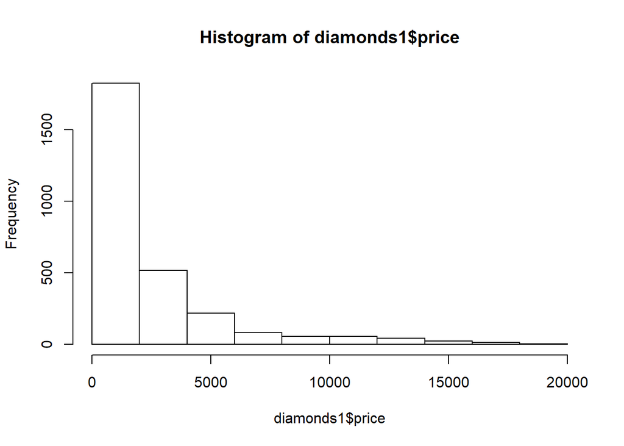

```r
hist(diamonds1$price)
```

```r
D <- diamonds1 %>%
  select(carat, price) %>%
  filter(price <= 5000)
```

Our distribution is a little more normal as we do this, but it is still far from it.

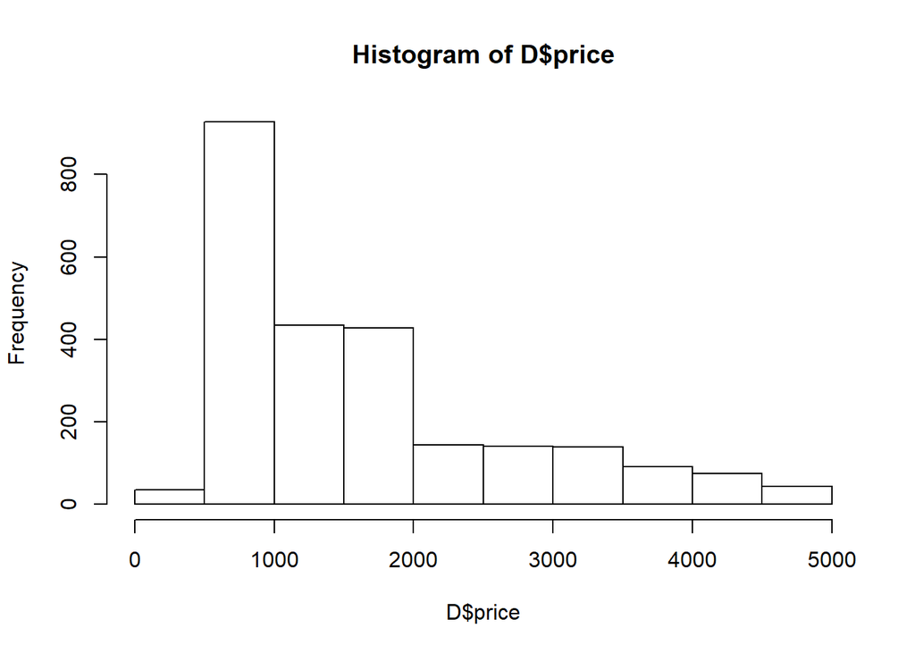

```r
hist(D$price)
```

## Insights for Y variable: CARAT

As we look at our 5 number summary for the carat of the diamonds in our data, we notice that the data is skewed to the right. The mean is greater than the median, meaning that more of the data is found to be greater than the median.

```r
pander(favstats(D$carat))
```

| min | Q1 | median | Q3 | max | mean | sd | n | missing |
| --- | --- | --- | --- | --- | --- | --- | --- | --- |
| 0.2 | 0.32 | 0.42 | 0.56 | 1.18 | 0.4726 | 0.1694 | 2455 | 0 |

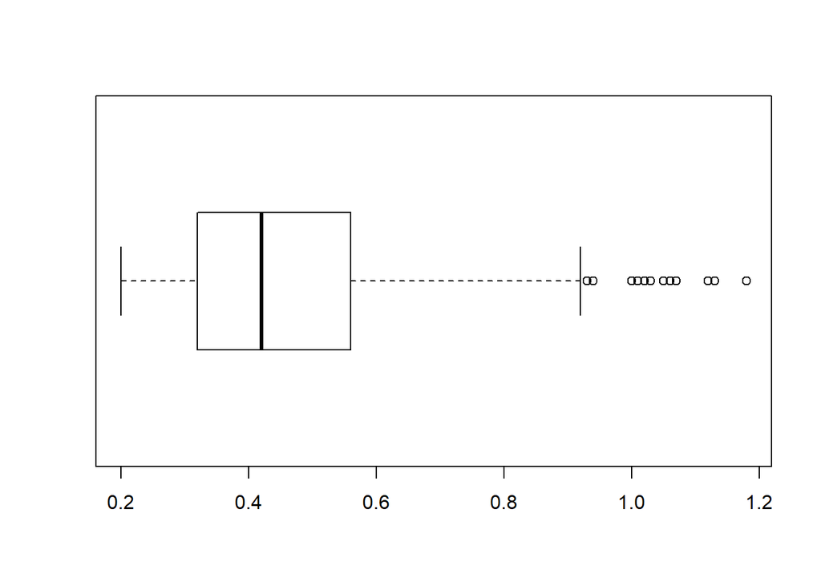

```r
boxplot(D$carat, horizontal = TRUE)
```

## The Plot/Lowess Curve

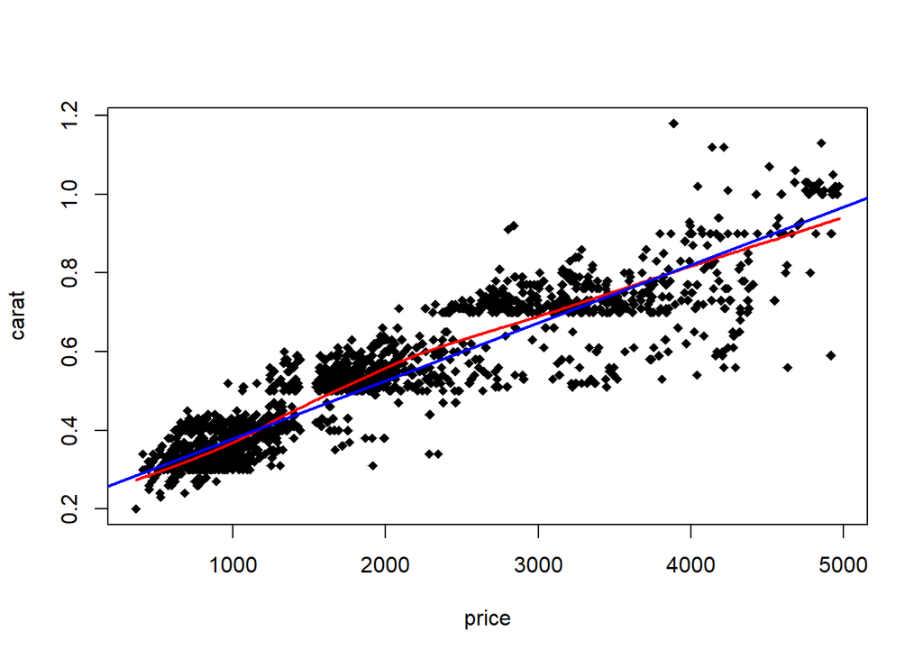

```r
plot(carat ~ price, data = D, pch = 18)
lines(lowess(D$price, D$carat), col = "red", lwd = 2)
D.lm <- lm(carat ~ price, data =D)
abline(D.lm, col = "blue", lwd = 2)
```

## Alternative Conclusions and Decision Rule

We will be testing $\beta_1$ because it’s our slope that’s in question. Our alternative conclusions are as follows:

$$Y_i = \beta_0 + \beta_1 * X_i + \epsilon_i$$

$$where \ \ \epsilon_i ~ N(0,\sigma^2)$$

$$H_o: \beta_1 = 0$$

$$H_a: \beta_1 \neq 0$$
$$\alpha = 0.05$$

```r
pander(summary(D.lm))
```

|  | Estimate | Std. Error | t value | Pr(>\|t\|) |
| --- | --- | --- | --- | --- |
| **(Intercept)** | 0.2318 | 0.002392 | 96.92 | 0 |
| **price** | 0.0001471 | 1.225e-06 | 120.1 | 0 |

Fitting linear model: carat ~ price

| Observations | Residual Std. Error | $R^2$ | Adjusted $R^2$ |
| --- | --- | --- | --- |
| 2455 | 0.06458 | 0.8546 | 0.8546 |

We want to determine if there is a linear relation between the diamond’s carat and the price. To do this we will test our decision rule:

- If |t*| <= t(1-$\alpha$/2; n - 2), conclude $H_0$
- If |t*| > t(1-$\alpha$/2; n - 2), conclude $H_a$

```r
pander(qt(1-0.05/2, length(D$price-2)))
```

*1.961*

t* = 120.1

t = 1.961

Therefore, we conclude that $\beta_1 \neq 0$, meaning that there is a linear relationship between price and carat.

## Assumptions and Departures from the Model

- The regression function is linear
- The error terms have constant variance
- The error terms are independent
- The model fits all outlier observations
- The error terms are normally distributed
- All important predictor variables have been included in the model

### Normality of the Residuals

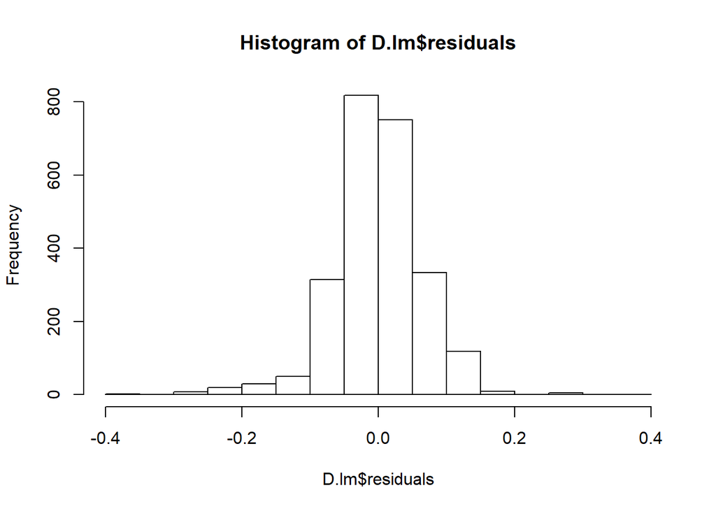

```r
hist(D.lm$residuals)
```

### Residual vs. Fitted

We notice that our variance doesn’t look constant. As we move down the graph, we notice that the residuals get wider spread apart. This means that we need a y-axis transformation to resolve this. There seems to be chaos displayed here, but there seems to be “chunks” which may suggest that there is a variable that we haven’t included with our data that could be of importance.

Is there a pattern here that we aren’t taking into account? There are “chunks”.

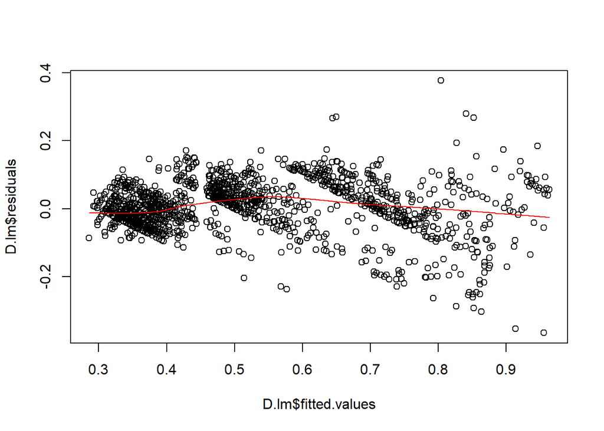

```r
plot(D.lm$residuals ~ D.lm$fitted.values)
lines(lowess(D.lm$fitted.values, D.lm$residuals), col = "red")
```

### Sequence Plot

For the most part, there seems to be independent error terms except for something happening at Index 500. This may have come from the same issue in our Residual vs. Fitted plot.

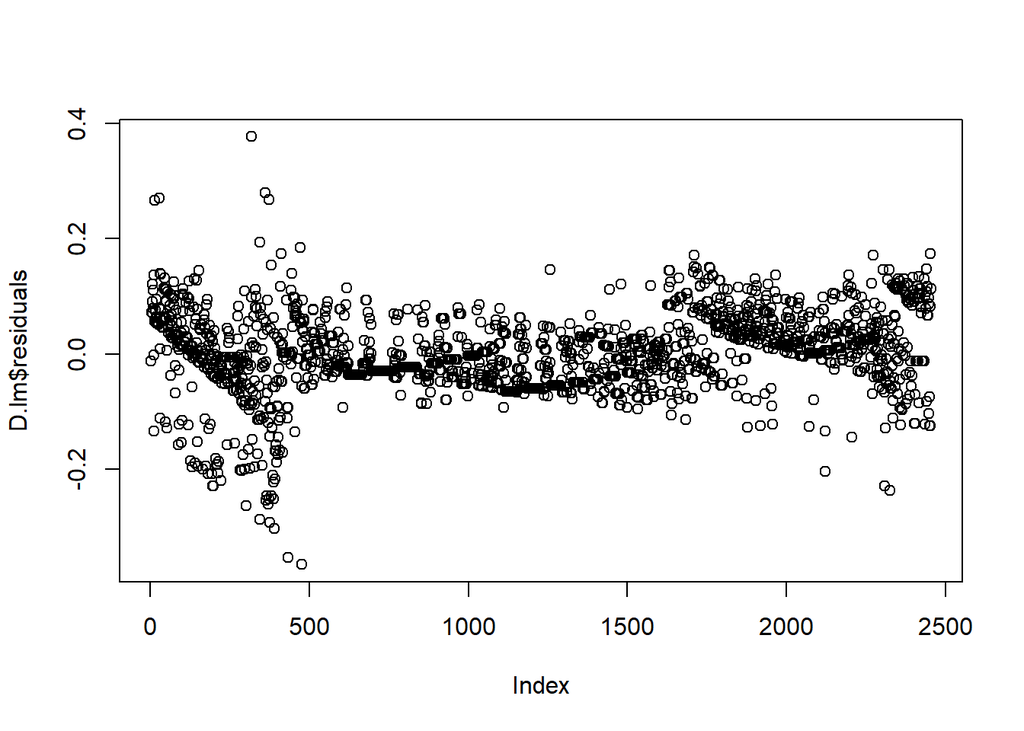

```r
plot(D.lm$residuals)
```

### QQ-plot

Our distribution of the data seems to be normal for the most part, except for the ends. This, as well, may be due to missing data from our model.

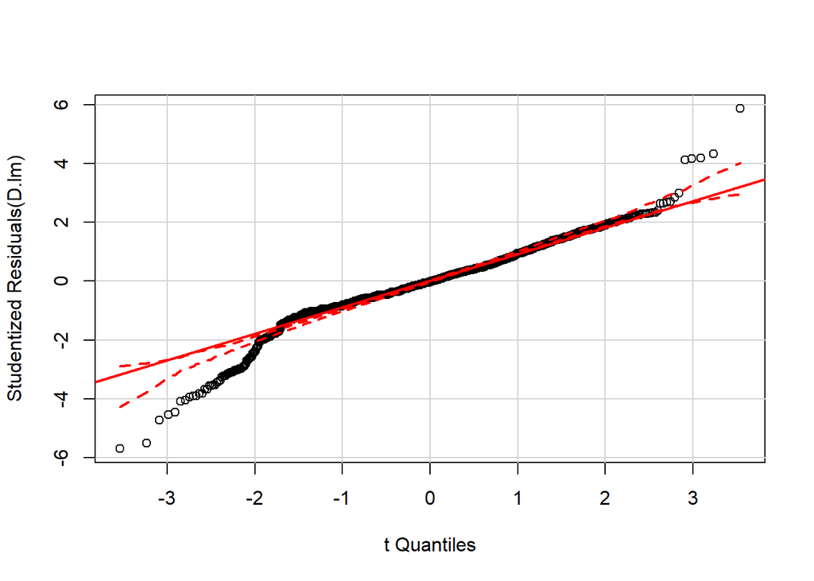

```r
qqPlot(D.lm)
```

## Transformed Model

In order to perform transformations on these data, we need to perform a Box Cox test to determine lamba and the appropriate transformation. Unfortunately, due to the type of data set that our diamonds data is called to, tibbles cannot be used in a Box Cox test. Due to the our R-squared value being able to explain 85 percent of our data, we will dismiss transformations for our regression.

## Confidence Interval and Data Prediction

```r
pred <- predict(D.lm, data.frame(price = 1000), interval="prediction")
conf <- predict(D.lm, data.frame(price = 1000), interval="confidence")
```

Because most students can’t afford thousands of dollars for a ring, we will assume that a student has a budget of $1000 to purchase a ring. Our prediction interval is found in red and our confidence interval is found in blue. Both are at a 95% confidence. We see that average of every diamond found at $1000 is between 0.376 and 0.3819 carats. For any particular diamond, it can be found between 0.2523 and 0.5056 carats.

```r
pred
```

```
##         fit      lwr       upr
## 1 0.3789449 0.252266 0.5056238
```

```r
conf
```

```
##         fit      lwr       upr
## 1 0.3789449 0.375966 0.3819238
```

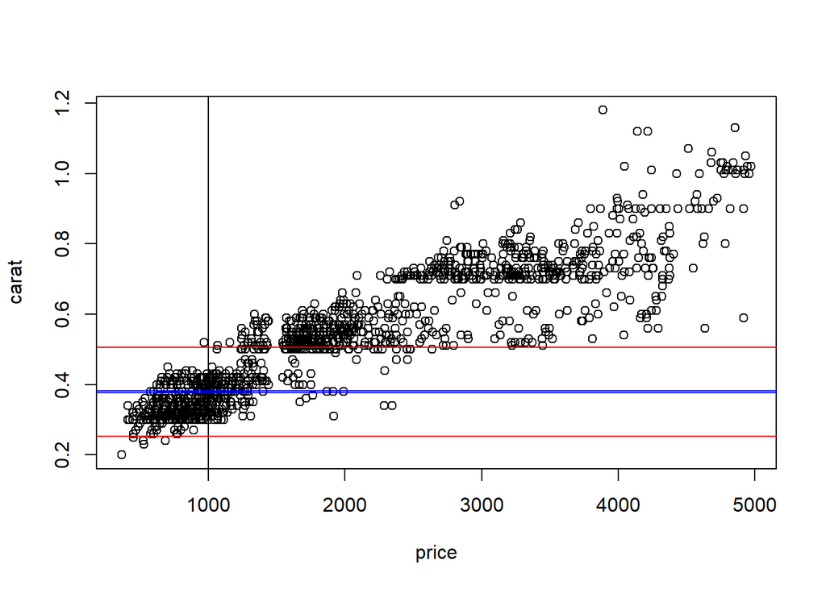

```r
plot(carat ~ price, data = D)
abline(v = 1000)
abline(h = c(conf[2], conf[3]), col = "blue")
abline(h = c(pred[2], pred[3]), col = "red")
```